# Assesmnt2_BUS1039_Predictive Analytics

Anthonia Fisuyi

2023-04-06

# Data-Driven Bank Telemarketing Concept.

- Statistical Modeling Approach;
  1. Data Exploration and Feature Selection using RFEand Random Forest (RF)
  2. DM Model:
     1. Probability outputs:logistic regression (LR), Decision trees(DTs) ,Neural Networks(NN), Naive Bayes (NB), and Random Forest (RF)
  3. K-fold cross-validation techniques
     1. using a 10 fold cross validation for all proposed statistical model provides a more accurate estimate of each model’s performance than simply evaluating the model on a single test set.
     2. It also allows for the use of all available data for training and validation, which can be important for small datasets.
  4. Evaluation Metrics : + Confusion Matrix which helps compare predictions of a model with actual results + Area Under the ROC Curve (AUC – ROC) plot between model sensitivity and specificity + Predictive metric : MAE and ME + Performance metric: Accuracy, recall, precision and f1 score

## 1. Clearing environment , loading appropriate libraries and reading datasets

### Setting Working Directory

```r
rm(list=ls())

setwd("C:/Users/Probook/iCloudDrive/ClassBizAnaBigD/Semester2/BU51039_Prescriptive and Predictive Analytics/Assessmnt")
```

### Loading Libraries

```r
library(readr)
library("ggplot2")
library("tidyverse")
library("fpp2")
library("dplyr") # for data wrangling
library("DataExplorer") # for exploratory data analysis
library("class") # for exploratory data analysis


library(caret) # for implementing RFE for feature selection
library(randomForest) #for implementing RFE for feature selection
library(e1071) # for Naive
library(rpart) # for DT
library(rpart.plot) # for DT
library(nnet) # for NN

# set seed for reproducibility
set.seed(123)
```

### Importing Dataset

```r
test <- read_csv("test.csv" )
train <- read_csv("train.csv")
head(train)
```

```
## # A tibble: 6 × 17
##     age job        marital education default balance housing loan  contact   day
##   <dbl> <chr>      <chr>   <chr>     <chr>     <dbl> <chr>   <chr> <chr>   <dbl>
## 1    44 technician single  secondary no           29 yes     no    unknown     5
## 2    33 entrepren… married secondary no            2 yes     yes   unknown     5
## 3    47 blue-coll… married unknown   no         1506 yes     no    unknown     5
## 4    33 unknown    single  unknown   no            1 no      no    unknown     5
## 5    35 management married tertiary  no          231 yes     no    unknown     5
## 6    28 management single  tertiary  no          447 yes     yes   unknown     5
## # ℹ 7 more variables: month <chr>, duration <dbl>, campaign <dbl>, pdays <dbl>,
## #   previous <dbl>, poutcome <chr>, y <dbl>
```

```r
head(test)
```

```
## # A tibble: 6 × 17
##     age job        marital education default balance housing loan  contact   day
##   <dbl> <chr>      <chr>   <chr>     <chr>     <dbl> <chr>   <chr> <chr>   <dbl>
## 1    58 management married tertiary  no         2143 yes     no    unknown     5
## 2    57 blue-coll… married primary   no           52 yes     no    unknown     5
## 3    56 management married tertiary  no          779 yes     no    unknown     5
## 4    44 admin.     married secondary no         -372 yes     no    unknown     5
## 5    49 management married tertiary  no          378 yes     no    unknown     5
## 6    51 management married tertiary  no        10635 yes     no    unknown     5
## # ℹ 7 more variables: month <chr>, duration <dbl>, campaign <dbl>, pdays <dbl>,
## #   previous <dbl>, poutcome <chr>, y <dbl>
```

## 2. Exploratory Analysis

Exploring the dataset to gain an understanding of its structure and content. This includes looking at summary statistics, identifying missing values, outliers, and visualizing the data.

### Data Exploration

```r
# Code adapted from Garrett Grolemund's R for Data Science (2017)
# https://r4ds.had.co.nz/

str(train)
```

```
## spc_tbl_ [31,648 × 17] (S3: spec_tbl_df/tbl_df/tbl/data.frame)
##  $ age      : num [1:31648] 44 33 47 33 35 28 42 58 43 41 ...
##  $ job      : chr [1:31648] "technician" "entrepreneur" "blue-collar" "unknown" ...
##  $ marital  : chr [1:31648] "single" "married" "married" "single" ...
##  $ education: chr [1:31648] "secondary" "secondary" "unknown" "unknown" ...
##  $ default  : chr [1:31648] "no" "no" "no" "no" ...
##  $ balance  : num [1:31648] 29 2 1506 1 231 ...
##  $ housing  : chr [1:31648] "yes" "yes" "yes" "no" ...
##  $ loan     : chr [1:31648] "no" "yes" "no" "no" ...
##  $ contact  : chr [1:31648] "unknown" "unknown" "unknown" "unknown" ...
##  $ day      : num [1:31648] 5 5 5 5 5 5 5 5 5 5 ...
##  $ month    : chr [1:31648] "may" "may" "may" "may" ...
##  $ duration : num [1:31648] 151 76 92 198 139 217 380 50 55 222 ...
##  $ campaign : num [1:31648] 1 1 1 1 1 1 1 1 1 1 ...
##  $ pdays    : num [1:31648] -1 -1 -1 -1 -1 -1 -1 -1 -1 -1 ...
##  $ previous : num [1:31648] 0 0 0 0 0 0 0 0 0 0 ...
##  $ poutcome : chr [1:31648] "unknown" "unknown" "unknown" "unknown" ...
##  $ y        : num [1:31648] 0 0 0 0 0 0 0 0 0 0 ...
##  - attr(*, "spec")=
##   .. cols(
##   ..   age = col_double(),
##   ..   job = col_character(),
##   ..   marital = col_character(),
##   ..   education = col_character(),
##   ..   default = col_character(),
##   ..   balance = col_double(),
##   ..   housing = col_character(),
##   ..   loan = col_character(),
##   ..   contact = col_character(),
##   ..   day = col_double(),
##   ..   month = col_character(),
##   ..   duration = col_double(),
##   ..   campaign = col_double(),
##   ..   pdays = col_double(),
##   ..   previous = col_double(),
##   ..   poutcome = col_character(),
##   ..   y = col_double()
##   .. )
##  - attr(*, "problems")=<externalptr>
```

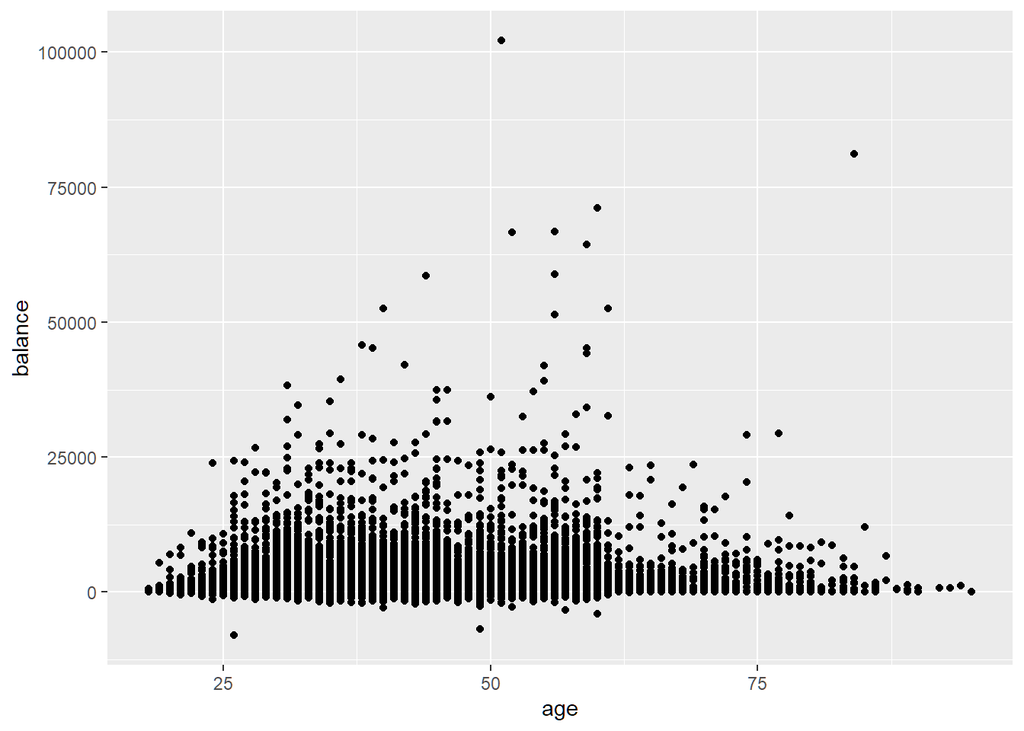

```r
# Remove non-numeric columns
train_numeric <- train %>% select_if(is.numeric)

#library(ggplot2)
ggplot(train, aes(x = age, y = balance)) + geom_point()
```

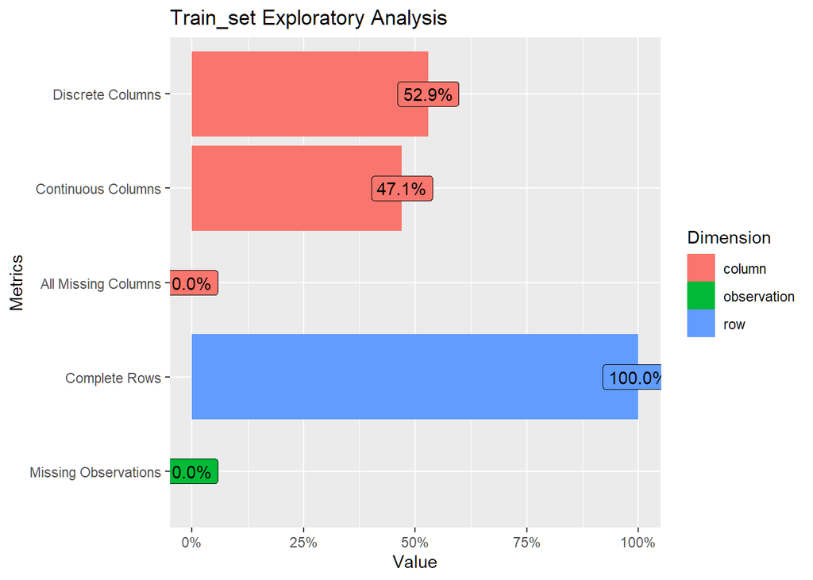

```r
DataExplorer::plot_intro(train , title = "Train_set Exploratory Analysis") # check the types of variables
```

```r
# Identify outliers using Z-score method
z_scores <- scale(train_numeric)
outliers <- rowSums(z_scores >= 3) > 0

# Print number of outliers
cat("Number of outliers:", sum(outliers))
```

```
## Number of outliers: 3593
```

### Correlation Analysis

- A corrolation plot can be plotted on the numerical data to find features that are highly positively correlated and to be included in features for fitting the DM model

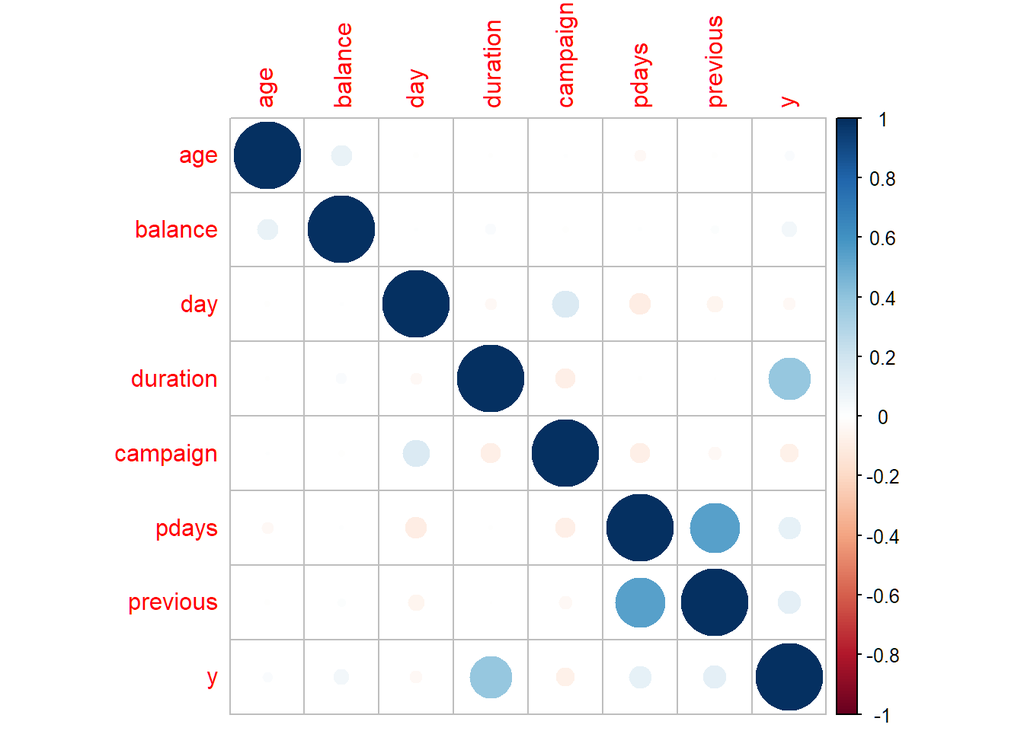

```r
library(car)
library(corrplot)

corrplot(cor(train_numeric)) ## the 'darker' the circles, the more positively correlated the variables.
```

## 3. Data Preprocessing.

### Missing Data

```r
#train <- na.omit(train) ~ no missing data so step is excluded
```

#### Handling Outlier

The Winsorization method is to be used for dealing with outliers. It requires utilising a function from the DescTools package to swap out the extreme values for the nearest non-extreme value

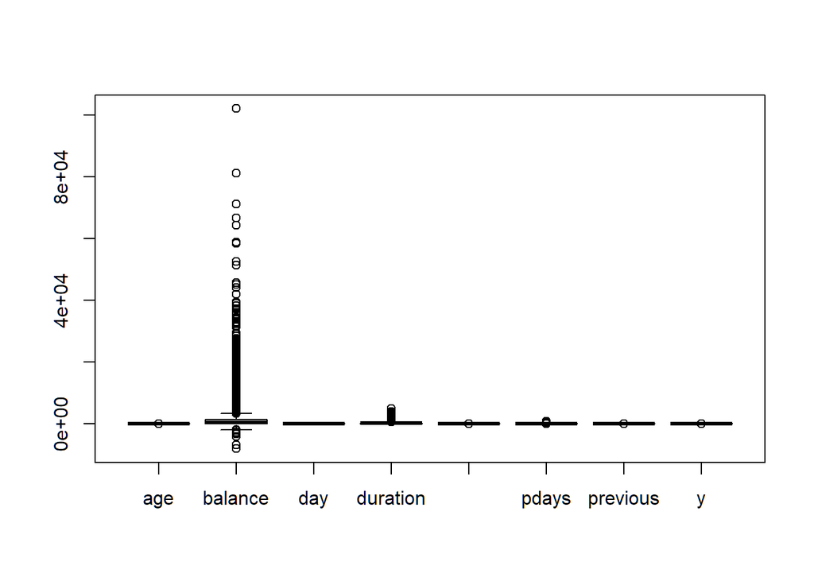

```r
boxplot(train_numeric , title = "Train_set Outliers")
```

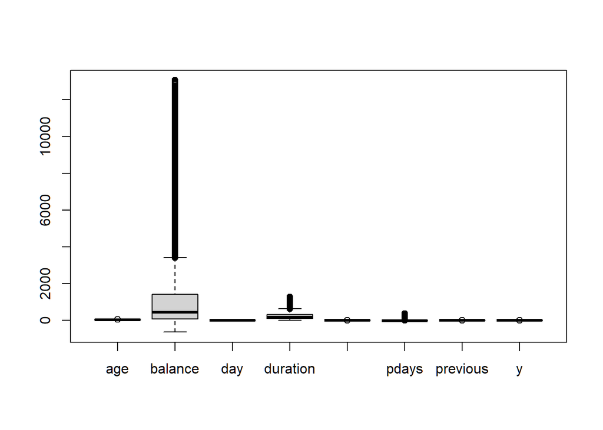

```r
#code adapted from https://search.r-project.org/CRAN/refmans/DescTools/html/Winsorize.html#:~:text=Winsorizing%20a%20vector%20means%20that,the%20most%20extreme%20retained%20values.

#get all numeric variable column names
train_outl <- train %>%  select_if(is.numeric) %>%  names()

# Winsorize all numeric variables at the 1% level
train_cleaned <- train %>%
  mutate_at(vars(all_of(train_outl)), list(~DescTools::Winsorize(., probs=c(0.01, 0.99))))

boxplot(train_cleaned%>%  select_if(is.numeric) ,
        title = " Cleaned Train_set")
```

### Encoding

```r
# Code adapted from Garrett Grolemund's R for Data Science (2017)
# https://r4ds.had.co.nz/

# recoding categorical features as factors
train <- train %>%   mutate_if(is.character, factor)
test <- test %>%    mutate_if(is.character, factor)


# recoding target variable as factor
train$y <- as.factor(train$y)
test$y <- as.factor(test$y)

table(train$y) # view result
```

```
##
##     0     1
## 27920  3728
```

### Feature Selection

```r
# codes adapted from Okan Bulut (2021) Effective Feature Selection: Recursive Feature Elimination Using R
#https://towardsdatascience.com/effective-feature-selection-recursive-feature-elimination-using-r-148ff998e4f7#:~:text=Recursive%20Feature%20Elimination%C2%B2%2C%20or%20shortly,the%20optimal%20combination%20of%20features.

# Set up the RFE control parameters
set.seed(123)

rfctrl <- rfeControl(functions = rfFuncs, method = "cv", number = 10, verbose = FALSE) #traincontrol

# Features
x <- train %>% select(-ncol(train)) %>%  as.data.frame()

# Target variable
y <- train$y

# Run RFE
rfemodel <- rfe(x = x, y = y, rfeControl = rfctrl, method = "rf" ,
                 sizes = c(10),  ntree=100)

# Print important variables
varImp(rfemodel)
```

```
##            Overall
## duration 83.930790
## month    26.838810
## housing  14.834201
## contact  13.618408
## day      13.452436
## poutcome 12.053992
## age      11.380630
## pdays    10.422019
## campaign  6.374479
## previous  6.295751
## job       6.249016
```

#### Visualizing important variable(s)

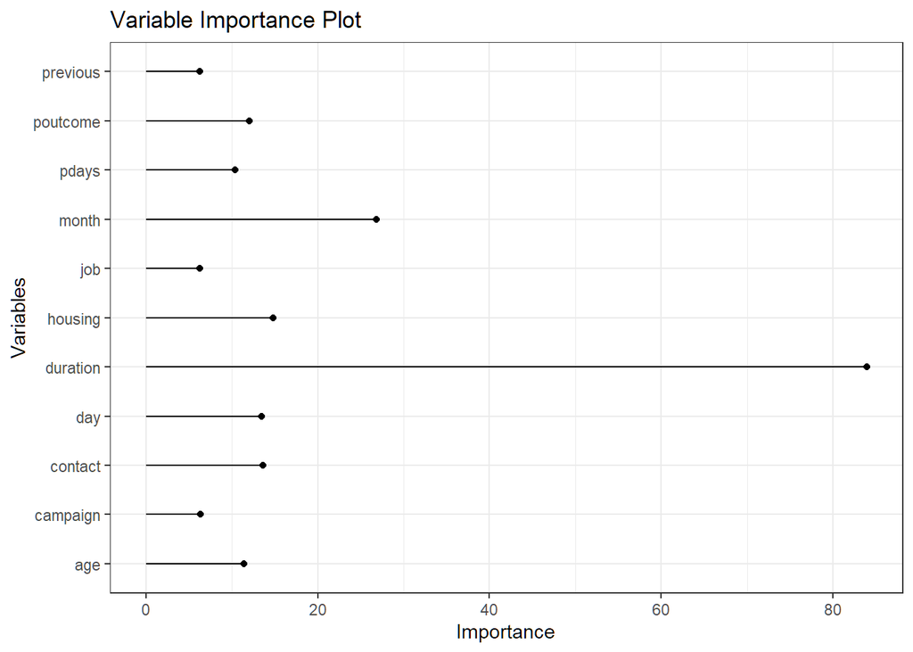

```r
set.seed(123)# ensure results are repeatable

important_var <- varImp(rfemodel, scale = FALSE) # estimate variable importance

# create a data frame for the variable importance
important_var_df <- data.frame(
  Variables = rownames(important_var),
  Importance = important_var$Overall)

# Save the table to a CSV file
write.table(important_var_df,
            file = 'Tables/ImportantFeatures.csv', sep = ",",
            row.names = FALSE)

# plot the variable importance using ggplot2
ggplot(important_var_df, aes(x = Importance, y = Variables)) +
  geom_point() +
  geom_segment(aes(x = 0, xend = Importance, y = Variables, yend = Variables)) +
  labs(x = "Importance", y = "Variables", title = "Variable Importance Plot") +
  theme_bw()
```

- Result further confirmed the inclusion of day, previous and duration as part of the predictor variables to be used in the predictive models:

## 4. DM models (train dataset)

### K-fold Validation

```r
# Code adapted from https://www.rdocumentation.org/packages/caret/versions/6.0-92/topics/trainControl
# specifying the cross-validation method
tctrl <- trainControl(method = "cv" , number = 10)
```

### Logistic Regression Model.

```r
# Code adapted from Garrett Grolemund's R for Data Science (2017)
# https://r4ds.had.co.nz/

set.seed(123)
# Subset the original dataset based on the selected features
train_set <- train_cleaned[, important_var_df$Variables]
test_set <- test[, important_var_df$Variables]

train_set$y <- train$y
test_set$y <- test$y


# Train a logistic regression model with the selected features
model_lr <- train(y ~. , data=train_set, method = "glm", family = "binomial", trControl = tctrl)

model_lr
```

```
## Generalized Linear Model
##
## 31648 samples
##    11 predictor
##     2 classes: '0', '1'
##
## No pre-processing
## Resampling: Cross-Validated (10 fold)
## Summary of sample sizes: 28483, 28483, 28483, 28483, 28484, 28483, ...
## Resampling results:
##
##   Accuracy   Kappa
##   0.9014471  0.4166242
```

following cross-validation, accuracy ( 0.9014471) which is the proportion of correct predictions made by the model is high , while a lower value for Cohen’s kappa (0.4166242) which measures the agreement between the model’s predictions and the true outcomes, taking into account the possibility of chance agreement is rather low an indication that the model might not perform well on the test set.

#### GLM Model Evaluation on test set

```r
# Code adapted from Dooruj Rambaccussing's Predictive Analytics (2023)

set.seed(123)

test$prediction_logistic <- predict(model_lr, newdata = test_set)

confusionMatrix(test$prediction_logistic, test_set$y)
```

```
## Confusion Matrix and Statistics
##
##           Reference
## Prediction     0     1
##          0 11689   978
##          1   313   583
##
##                Accuracy : 0.9048
##                  95% CI : (0.8998, 0.9097)
##     No Information Rate : 0.8849
##     P-Value [Acc > NIR] : 4.874e-14
##
##                   Kappa : 0.4264
##
##  Mcnemar's Test P-Value : < 2.2e-16
##
##             Sensitivity : 0.9739
##             Specificity : 0.3735
##          Pos Pred Value : 0.9228
##          Neg Pred Value : 0.6507
##              Prevalence : 0.8849
##          Detection Rate : 0.8618
##    Detection Prevalence : 0.9339
##       Balanced Accuracy : 0.6737
##
##        'Positive' Class : 0
##
```

- from the confusion matrix, only 583 good classifications when we would have liked to get all of them correct at 1561.

### Random Forest

Running a simple random forest with adjusted hyperparameter and using only the top predictors from the rfe model

```r
set.seed(123)

model_rf <- train(y ~. ,train_set, method = "rf", ntree = 200, trControl = tctrl)
model_rf
```

```
## Random Forest
##
## 31648 samples
##    11 predictor
##     2 classes: '0', '1'
##
## No pre-processing
## Resampling: Cross-Validated (10 fold)
## Summary of sample sizes: 28483, 28483, 28483, 28483, 28484, 28483, ...
## Resampling results across tuning parameters:
##
##   mtry  Accuracy   Kappa
##    2    0.8938954  0.1960127
##   18    0.9018895  0.4731540
##   34    0.9000570  0.4676685
##
## Accuracy was used to select the optimal model using the largest value.
## The final value used for the model was mtry = 18.
```

#### RF Model Evaluation on test set

```r
test$prediction_rf = predict(model_rf,test_set , type = "raw")
confusionMatrix(test$prediction_rf, test_set$y)
```

```
## Confusion Matrix and Statistics
##
##           Reference
## Prediction     0     1
##          0 11567   800
##          1   435   761
##
##                Accuracy : 0.9089
##                  95% CI : (0.904, 0.9137)
##     No Information Rate : 0.8849
##     P-Value [Acc > NIR] : < 2.2e-16
##
##                   Kappa : 0.5024
##
##  Mcnemar's Test P-Value : < 2.2e-16
##
##             Sensitivity : 0.9638
##             Specificity : 0.4875
##          Pos Pred Value : 0.9353
##          Neg Pred Value : 0.6363
##              Prevalence : 0.8849
##          Detection Rate : 0.8528
##    Detection Prevalence : 0.9118
##       Balanced Accuracy : 0.7256
##
##        'Positive' Class : 0
##
```

- from the confusion matrix, only 761 good classifications when we would have liked to get all of them correct at 1561.

### Naive Bayes model

```r
model_nb <- naiveBayes(y ~ ., data = train_set)

model_nb
```

```
##
## Naive Bayes Classifier for Discrete Predictors
##
## Call:
## naiveBayes.default(x = X, y = Y, laplace = laplace)
##
## A-priori probabilities:
## Y
##         0         1
## 0.8822042 0.1177958
##
## Conditional probabilities:
##    duration
## Y       [,1]     [,2]
##   0 219.7220 193.4328
##   1 514.7908 334.4414
##
##    month
## Y           apr         aug         dec         feb         jan         jul
##   0 0.058237822 0.139111748 0.003116046 0.056196275 0.032700573 0.156446991
##   1 0.105686695 0.127950644 0.018508584 0.082349785 0.028701717 0.115879828
##    month
## Y           jun         mar         may         nov         oct         sep
##   0 0.120916905 0.005372493 0.321955587 0.087858166 0.010064470 0.008022923
##   1 0.111319742 0.048551502 0.174892704 0.074034335 0.060890558 0.051233906
##
##    housing
## Y          no       yes
##   0 0.4199499 0.5800501
##   1 0.6354614 0.3645386
##
##    contact
## Y     cellular  telephone    unknown
##   0 0.62256447 0.06264327 0.31479226
##   1 0.82778970 0.07162017 0.10059013
##
##    day
## Y       [,1]     [,2]
##   0 15.92453 8.305591
##   1 15.10193 8.518439
```

[output cut: 19 more lines]

```
##   1 2.137876 1.817479
##
##    previous
## Y        [,1]     [,2]
##   0 0.4462393 1.357289
##   1 1.0984442 1.998582
##
##    job
## Y        admin. blue-collar entrepreneur   housemaid  management     retired
##   0 0.113610315 0.226325215  0.033022923 0.028187679 0.204978510 0.044448424
##   1 0.120171674 0.133315451  0.024409871 0.020654506 0.246512876 0.098175966
##    job
## Y   self-employed    services     student  technician  unemployed     unknown
##   0   0.034957020 0.096167622 0.016547278 0.167156160 0.028080229 0.006518625
##   1   0.034066524 0.067596567 0.050429185 0.162553648 0.036212446 0.005901288
```

#### NB Model Evaluation on test set

```r
test$prediction_nb = predict(model_nb,newdata = test_set,  type = "class")

confusionMatrix(test$prediction_nb, test_set$y )
```

```
## Confusion Matrix and Statistics
##
##           Reference
## Prediction     0     1
##          0 10943   710
##          1  1059   851
##
##                Accuracy : 0.8696
##                  95% CI : (0.8638, 0.8752)
##     No Information Rate : 0.8849
##     P-Value [Acc > NIR] : 1
##
##                   Kappa : 0.4164
##
##  Mcnemar's Test P-Value : <2e-16
##
##             Sensitivity : 0.9118
##             Specificity : 0.5452
##          Pos Pred Value : 0.9391
##          Neg Pred Value : 0.4455
##              Prevalence : 0.8849
##          Detection Rate : 0.8068
##    Detection Prevalence : 0.8592
##       Balanced Accuracy : 0.7285
##
##        'Positive' Class : 0
##
```

- from the confusion matrix, only 851 good classifications when you would have liked to get all of them correct at 1561.

### Decision Tree model (DTs)

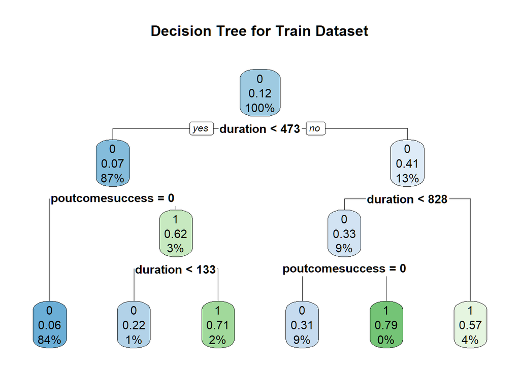

```r
# Code adapted from Dooruj Rambaccussing's Predictive Analytics (2023)

set.seed(123)
# Create a vector of values for the complexity parameter
cp_values <- seq(0.01, 0.5, by = 0.01)

model_dt <- train(y ~. , data= train_set,  method = "rpart",trControl = tctrl,
                tuneGrid = expand.grid(cp = cp_values) )

rpart.plot(model_dt$finalModel, main = "Decision Tree for Train Dataset") # plot decision tree
```

```r
model_dt
```

```
## CART
##
## 31648 samples
##    11 predictor
##     2 classes: '0', '1'
##
## No pre-processing
## Resampling: Cross-Validated (10 fold)
## Summary of sample sizes: 28483, 28483, 28483, 28483, 28484, 28483, ...
## Resampling results across tuning parameters:
##
##   cp    Accuracy   Kappa
##   0.01  0.8991089  0.3972896
##   0.02  0.8981295  0.3870168
##   0.03  0.8912096  0.2945556
##   0.04  0.8822043  0.0000000
##   0.05  0.8822043  0.0000000
##   0.06  0.8822043  0.0000000
##   0.07  0.8822043  0.0000000
##   0.08  0.8822043  0.0000000
##   0.09  0.8822043  0.0000000
##   0.10  0.8822043  0.0000000
##   0.11  0.8822043  0.0000000
##   0.12  0.8822043  0.0000000
##   0.13  0.8822043  0.0000000
##   0.14  0.8822043  0.0000000
##   0.15  0.8822043  0.0000000
##   0.16  0.8822043  0.0000000
##   0.17  0.8822043  0.0000000
##   0.18  0.8822043  0.0000000
##   0.19  0.8822043  0.0000000
##   0.20  0.8822043  0.0000000
##   0.21  0.8822043  0.0000000
##   0.22  0.8822043  0.0000000
##   0.23  0.8822043  0.0000000
##   0.24  0.8822043  0.0000000
##   0.25  0.8822043  0.0000000
##   0.26  0.8822043  0.0000000
##   0.27  0.8822043  0.0000000
##   0.28  0.8822043  0.0000000
```

[output cut: 10 more lines]

```
##   0.39  0.8822043  0.0000000
##   0.40  0.8822043  0.0000000
##   0.41  0.8822043  0.0000000
##   0.42  0.8822043  0.0000000
##   0.43  0.8822043  0.0000000
##   0.44  0.8822043  0.0000000
##   0.45  0.8822043  0.0000000
##   0.46  0.8822043  0.0000000
##   0.47  0.8822043  0.0000000
##   0.48  0.8822043  0.0000000
##   0.49  0.8822043  0.0000000
##   0.50  0.8822043  0.0000000
##
## Accuracy was used to select the optimal model using the largest value.
## The final value used for the model was cp = 0.01.
```

#### DT Model Evaluation on test set

```r
test$prediction_CART = predict(model_dt,test_set)
confusionMatrix(test$prediction_CART, test_set$y )
```

```
## Confusion Matrix and Statistics
##
##           Reference
## Prediction     0     1
##          0 11685   980
##          1   317   581
##
##                Accuracy : 0.9044
##                  95% CI : (0.8993, 0.9093)
##     No Information Rate : 0.8849
##     P-Value [Acc > NIR] : 1.747e-13
##
##                   Kappa : 0.4241
##
##  Mcnemar's Test P-Value : < 2.2e-16
##
##             Sensitivity : 0.9736
##             Specificity : 0.3722
##          Pos Pred Value : 0.9226
##          Neg Pred Value : 0.6470
##              Prevalence : 0.8849
##          Detection Rate : 0.8615
##    Detection Prevalence : 0.9338
##       Balanced Accuracy : 0.6729
##
##        'Positive' Class : 0
##
```

The performance of the CART model is similar to the previous logistic regression model, with a slightly lower accuracy. The sensitivity and specificity values are also similar. Overall, both models seem to have performed similarly, and the choice of which model to use would depend on other factors such as interpretability, complexity, and computational efficiency (step 3).

### Neural Networks (NN) model

```r
#code adapted from https://cran.r-project.org/web/packages/caret/caret.pdf

set.seed(123)

# Define the hyperparameter grid
grid <- expand.grid(size = c(1, 2, 3), decay = c(0, 0.01, 0.1))

model_nn <- train(y ~ ., data = train_set, method = "nnet", trControl = tctrl,tuneGrid = grid,
                  hidden=3, act.fct = "logistic", trace = FALSE, maxit = 1000)

model_nn
```

```
## Neural Network
##
## 31648 samples
##    11 predictor
##     2 classes: '0', '1'
##
## No pre-processing
## Resampling: Cross-Validated (10 fold)
## Summary of sample sizes: 28483, 28483, 28483, 28483, 28484, 28483, ...
## Resampling results across tuning parameters:
##
##   size  decay  Accuracy   Kappa
##   1     0.00   0.8842896  0.0490278
##   1     0.01   0.8936108  0.2769650
##   1     0.10   0.8915570  0.2342415
##   2     0.00   0.8925992  0.2811296
##   2     0.01   0.8954435  0.2888321
##   2     0.10   0.9007831  0.4256370
##   3     0.00   0.8880181  0.1788283
##   3     0.01   0.9041327  0.4889408
##   3     0.10   0.9044803  0.4785064
##
## Accuracy was used to select the optimal model using the largest value.
## The final values used for the model were size = 3 and decay = 0.1.
```

#### NN Model Evaluation on test set

```r
test$prediction_nn = predict(model_nn,test_set)

confusionMatrix(test$prediction_nn, test_set$y)
```

```
## Confusion Matrix and Statistics
##
##           Reference
## Prediction     0     1
##          0 11605   830
##          1   397   731
##
##                Accuracy : 0.9095
##                  95% CI : (0.9046, 0.9143)
##     No Information Rate : 0.8849
##     P-Value [Acc > NIR] : < 2.2e-16
##
##                   Kappa : 0.4949
##
##  Mcnemar's Test P-Value : < 2.2e-16
##
##             Sensitivity : 0.9669
##             Specificity : 0.4683
##          Pos Pred Value : 0.9333
##          Neg Pred Value : 0.6480
##              Prevalence : 0.8849
##          Detection Rate : 0.8556
##    Detection Prevalence : 0.9168
##       Balanced Accuracy : 0.7176
##
##        'Positive' Class : 0
##
```

## 5. Results

### Evaluating DM model performance: ROC(AUC) curve

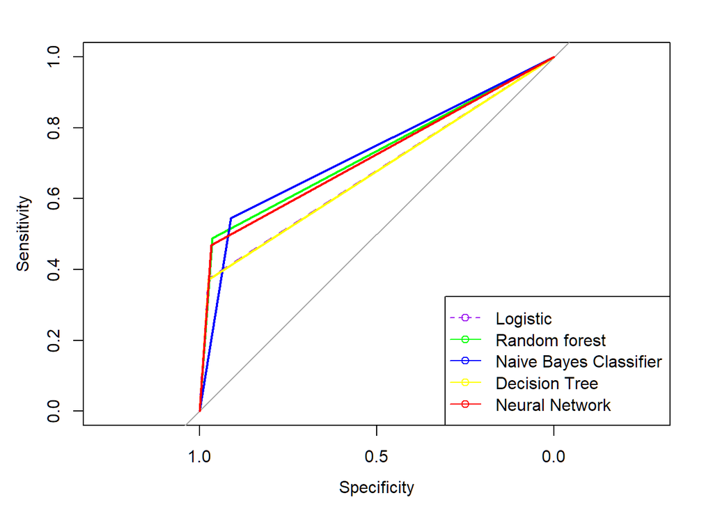

```r
# Code adapted from Dooruj Rambaccussing's Predictive Analytics (2023)

library(pROC)

roc_lr <- roc(as.numeric(test_set$y),as.numeric(test$prediction_logistic ))
roc_rf <- roc(as.numeric(test_set$y),as.numeric(test$prediction_rf))
roc_nb <- roc(as.numeric(test_set$y),as.numeric(test$prediction_nb))
roc_dt <- roc(as.numeric(test_set$y),as.numeric(test$prediction_CART))
roc_nn <- roc(as.numeric(test_set$y),as.numeric(test$prediction_nn))


par(mar=c(4,4,3,2)+0.1) # Increase margin

plot(roc_lr, col = "purple" , lty = 2 )
lines(roc_rf, col = "green")
lines(roc_nb, col = "blue")
lines(roc_dt, col="yellow")
lines(roc_nn, col="red")

legend("bottomright",
       legend = c("Logistic", "Random forest", "Naive Bayes Classifier",
                  "Decision Tree" ,"Neural Network"),
       col = c("purple", "green", "blue","yellow", "red"),
       lty  = c(2, 1, 1, 1, 1),  pch = 1)
```

### kappa and AUC Values

```r
#code adapted from https://cran.r-project.org/web/packages/caret/caret.pdf

# print the AUC values
cat("AUC of LR model:", auc(roc_lr), "\n",
    "AUC of Random Forest model:", auc(roc_rf), "\n",
    "AUC of Naive Bayes model:", auc(roc_nb), "\n",
    "AUC of Decision Tree model:", auc(roc_dt), "\n",
    "AUC of Neural Network model:", auc(roc_nn), "\n")
```

```
## AUC of LR model: 0.6736998
##  AUC of Random Forest model: 0.725632
##  AUC of Naive Bayes model: 0.728464
##  AUC of Decision Tree model: 0.6728925
##  AUC of Neural Network model: 0.7176059
```

```r
## # Extract kappa coefficient
k_lr <- confusionMatrix(test$prediction_logistic, test_set$y)$overall['Kappa']
k_rf <- confusionMatrix(test$prediction_rf, test_set$y)$overall['Kappa']
k_nb <- confusionMatrix(test$prediction_nb, test_set$y)$overall['Kappa']
k_dt <- confusionMatrix(test$prediction_CART, test_set$y)$overall['Kappa']
k_nn <- confusionMatrix(test$prediction_nn, test_set$y)$overall['Kappa']


cat("\n",
    "Kappa for LR model:", k_lr, "\n",
    "Kappa for Random Forest model:", k_rf, "\n",
    "Kappa for Naive Bayes model:", k_nb, "\n",
    "Kappa for Decision Tree model:", k_dt, "\n",
    "Kappa for Neural Network model:", k_nn, "\n")
```

```
##
##  Kappa for LR model: 0.4264145
##  Kappa for Random Forest model: 0.502357
##  Kappa for Naive Bayes model: 0.416431
##  Kappa for Decision Tree model: 0.4241426
##  Kappa for Neural Network model: 0.4949269
```

```r
# Create a data frame with model names and AUC and kappa values
auc_k_df <- data.frame(Model = c("LR", "RF", "NB", "DT", "NN"),
                       AUC = c(auc(roc_lr), auc(roc_rf), auc(roc_nb), auc(roc_dt), auc(roc_nn)),
                       kappa = c(k_lr, k_rf, k_nb, k_dt,k_nn))

# Write the data frame to a CSV file
write.csv(auc_k_df, file = "Tables/AUC_Kappa.csv", row.names = FALSE)
```

### Confusion Matrix Result and interpretation

```r
# confusion matrix codes adapted from: https://www.rdocumentation.org/packages/caret/versions/6.0-86/topics/confusionMatrix
# Code for writing a dataframe to a CSV file: https://www.rdocumentation.org/packages/utils/versions/3.6.2/topics/write.table


# print the Confusion Matrix values
cm_lr <- confusionMatrix(test$prediction_logistic, test_set$y)$table
cm_rf <- confusionMatrix(test$prediction_rf, test_set$y)$table
cm_nb <-confusionMatrix(test$prediction_nb, test_set$y)$table
cm_dt <-confusionMatrix(test$prediction_CART, test_set$y)$table
cm_nn <-confusionMatrix(test$prediction_nn, test_set$y)$table

# create a list of confusion matrices for each model
cm_list <- list(cm_lr, cm_rf, cm_nb, cm_dt, cm_nn)

# create a function to extract TP, TN, FP, and FN from each confusion matrix and return as a named vector
get_metrics <- function(cm) {
  TP <- cm[2,2]
  TN <- cm[1,1]
  FP <- cm[2,1]
  FN <- cm[1,2]
  return(c(TP = TP, TN = TN, FP = FP, FN = FN))}

# apply the function to each confusion matrix in the list
cm_vec_list <- lapply(cm_list, get_metrics)

# combine the vectors into a data frame with one column header
cm_df <- data.frame(Model = c("LR", "RF", "NB", "DT", "NN"),
                    do.call(rbind, cm_vec_list))
rownames(cm_df) <- NULL # set row names
colnames(cm_df)[-1] <- c("TP", "TN", "FP", "FN") # set column names
cm_df # show the resulting data frame
```

```
##   Model  TP    TN   FP  FN
## 1    LR 583 11689  313 978
## 2    RF 761 11567  435 800
## 3    NB 851 10943 1059 710
## 4    DT 581 11685  317 980
## 5    NN 731 11605  397 830
```

```r
# Save the table to a CSV file
write.table(cm_df,
            file = 'Tables/ConfusionMatrix.csv', sep = ",",
            row.names = FALSE)
```

### DM Model(s) performance in terms of forecasting and prediction

```r
# Code for creating an empty dataframe to store the metrics adapted from: https://www.rdocumentation.org/packages/base/versions/3.6.2/topics/data.frame

# create a dataframe with the model confusion matrix results
models <- c("LR", "RF", "NB", "DT","NN")
TP <- cm_df$TP
TN <- cm_df$TN
FP <- cm_df$FP
FN <- cm_df$FN
data <- data.frame(Model = models, TP = TP, TN = TN, FP = FP, FN = FN)

# create an empty dataframe to store the metrics
metrics <- data.frame(Model = models, Accuracy = rep(NA, length(models)), Precision = rep(NA, length(models)), Sensitivity = rep(NA, length(models)), F1_Score = rep(NA, length(models)))

# calculate metrics for each model
for (i in 1:nrow(data)) {
  tp <- data[i, "TP"]
  tn <- data[i, "TN"]
  fp <- data[i, "FP"]
  fn <- data[i, "FN"]

  metrics[i, "Accuracy"] <- (tp + tn) / (tp + tn + fp + fn) # measures the proportion of correct predictions made by the model
  metrics[i, "Precision"] <- tp / (tp + fp) # measures the proportion of true positive predictions out of all the positive predictions
  metrics[i, "Sensitivity"] <- tp / (tp + fn) # measures the proportion of true positive predictions out of all the actual positive cases
  metrics[i, "F1_Score"] <- 2 * (metrics[i, "Precision"] * metrics[i, "Sensitivity"]) / (metrics[i, "Precision"] + metrics[i, "Sensitivity"])# a measure of the overall performance of the model
  }

metrics_df <- as.data.frame(metrics)
metrics_df
```

```
##   Model  Accuracy Precision Sensitivity  F1_Score
## 1    LR 0.9048146 0.6506696   0.3734785 0.4745625
## 2    RF 0.9089434 0.6362876   0.4875080 0.5520493
## 3    NB 0.8695716 0.4455497   0.5451634 0.4903486
## 4    DT 0.9043722 0.6469933   0.3721973 0.4725498
## 5    NN 0.9095333 0.6480496   0.4682896 0.5436965
```

```r
# Save the table to a CSV file
write.table(metrics_df,
            file = 'Tables/PerformanceMetrics.csv', sep = ",",
            row.names = FALSE)
```

*Accuracy: the proportion of correct predictions out of total predictions made. Higher accuracy is better.* *Precision: the proportion of correct positive predictions out of total positive predictions made. Higher precision is better.* *Recall: the proportion of actual positive cases that are correctly identified. Higher recall is better.* *F1-score: the harmonic mean of precision and recall. Higher F1-score is better.*

```r
# MAE and ME evaluation: caret package
#(https://cran.r-project.org/web/packages/caret/index.html)

# Calculate MAE and ME for each model
mae_lr <- mean(abs(as.numeric(test$prediction_logistic) - as.numeric(test_set$y)))
me_lr <- mean(as.numeric(as.character(test$prediction_logistic)) - as.numeric(as.character(test_set$y)))

mae_rf <- mean(abs(as.numeric(test$prediction_rf) - as.numeric(test_set$y)))
me_rf <- mean(as.numeric(as.character(test$prediction_rf)) - as.numeric(as.character(test_set$y)))

mae_nb <- mean(abs(as.numeric(test$prediction_nb) - as.numeric(test_set$y)))
me_nb <- mean(as.numeric(as.character(test$prediction_nb)) - as.numeric(as.character(test_set$y)))

mae_dt <- mean(abs(as.numeric(test$prediction_CART) - as.numeric(test_set$y)))
me_dt <- mean(as.numeric(as.character(test$prediction_CART)) - as.numeric(as.character(test_set$y)))

mae_nn <- mean(abs(as.numeric(test$prediction_nn) - as.numeric(test_set$y)))
me_nn <- mean(as.numeric(as.character(test$prediction_nn)) - as.numeric(as.character(test_set$y)))


# Store results in a dataframe
PredictiveMetric_df <- data.frame(Model = c("LR", "RF", "NB", "DT", "NN"),
                        MAE = c(mae_lr, mae_rf, mae_nb, mae_dt, mae_nn ),
                        ME = c(me_lr, me_rf, me_nb, me_dt, me_nn))
PredictiveMetric_df
```

```
##   Model        MAE          ME
## 1    LR 0.09518543 -0.04903045
## 2    RF 0.09105655 -0.02691145
## 3    NB 0.13042837  0.02573177
## 4    DT 0.09562781 -0.04888299
## 5    NN 0.09046671 -0.03192509
```

```r
# Save the table to a CSV file
write.table(PredictiveMetric_df,
            file = 'Tables/PredictiveMetrics.csv', sep = ",",
            row.names = FALSE)
```

## 6. Corporate Purpose and limitations of the study.

based on the confusion matrix result, the company can evaluate the performance of the model and decide how to allocate its resources for the campaign efforts. For example, the company can prioritize its campaign on customers who are predicted to buy in to the service (TP) and customers who are likely to buy in but not predicted by the model (FN) in order to reduce campaign cost and increase revenue. On the other hand, the company can avoid targeting customers who are predicted not to buy in (TN) in order to reduce unnecessary costs.